# Statistical Analysis: Feedback Processing

2026-08-13

# Preparation

In this section, we load the packages required for the subsequent analyses.

```r
# Data manipulation
library(tidyverse)
library(tidyr)
library(dplyr)

# Descriptive statistics
library(psych)

# Visualization
library(ggplot2)
library(corrplot)

# MIxed models
library(lme4)
library(lmerTest)

# Estimated marginal means
library (emmeans)
```

```r
# Set fixed colours for our feedback conditions

feedback_colour <- "cornflowerblue"
control_colour <- "coral"

feedback_colours <- c(
  "Control" = control_colour,
  "Feedback" = feedback_colour
)
```

# Experimental Data

## Loading the Dataset

The experimental dataset containing reaction times and accuracy values is loaded from a CSV file.

```r
descr_df <- read_csv("Exp_longlist_merged_2026_07_02.csv", show_col_types = FALSE)
# descr_df
```

## Descriptive Statistics

Two main measures are analysed:

- **Accuracy** (whether the response was correct)
- **Reaction time (RT)** in milliseconds

### Initial Inspection of the Data

Before conducting statistical analyses, the dataset is filtered to include only experimental trials containing real words. This removes practice items and nonword trials.

```r
# Remove all practice items, remove all nonword trials
pre_filtered_df <- subset(descr_df, Item_type == "exp" & Condition == "word")
pre_filtered_df
```

```
## # A tibble: 3,330 × 29
##    Participant Item_type Condition Stimulus Accuracy    RT Feedback Length Block
##          <dbl> <chr>     <chr>     <chr>       <dbl> <dbl>    <dbl>  <dbl> <dbl>
##  1        2001 exp       word      COUNCIL         1   728        1      7     1
##  2        2001 exp       word      ERRAND          0   533        1      6     1
##  3        2001 exp       word      HAIRLINE        1   713        1      8     1
##  4        2001 exp       word      SQUIRE          1   678        1      6     1
##  5        2001 exp       word      LICORICE        0   488        1      8     1
##  6        2001 exp       word      CIRCUIT         1   624        1      7     1
##  7        2001 exp       word      BASEMENT        1   610        1      8     1
##  8        2001 exp       word      VERDICT         1   616        1      7     1
##  9        2001 exp       word      JESTER          0   452        1      6     1
## 10        2001 exp       word      HENHOUSE        0   534        1      8     1
## # ℹ 3,320 more rows
## # ℹ 20 more variables: Lg10SUBTLEX_US <dbl>, age <dbl>, gender <chr>,
## #   age_of_acquisition <dbl>, proficiency_speaking <dbl>,
## #   proficiency_listening <dbl>, proficiency_reading <dbl>,
## #   proficiency_writing <dbl>, anxiety_score <dbl>,
## #   openness_to_experience <dbl>, conscientiousness <dbl>, extraversion <dbl>,
## #   agreeableness <dbl>, neuroticism <dbl>, education <chr>, …
```

### Participant-Level Summary Statistics

To identify potential outliers or problematic participants, we compute the mean accuracy and mean reaction time for each participant.

This allows us to detect:

- participants with extremely low accuracy (indicating misunderstanding of the task)
- participants with unusually slow responses

A preliminary plot is used to visualize potential outliers.

```r
# Overall overview by participant
describeBy(pre_filtered_df, group = pre_filtered_df$Participant)
```

```
##
##  Descriptive statistics by group
## group: 2001
##                        vars  n    mean     sd  median trimmed    mad     min
## Participant               1 90 2001.00   0.00 2001.00 2001.00   0.00 2001.00
## Item_type                 2 90    1.00   0.00    1.00    1.00   0.00    1.00
## Condition                 3 90    1.00   0.00    1.00    1.00   0.00    1.00
## Stimulus                  4 90   45.50  26.12   45.50   45.50  33.36    1.00
## Accuracy                  5 90    0.81   0.39    1.00    0.89   0.00    0.00
## RT                        6 90  718.86 337.93  615.00  651.67 117.87  452.00
## Feedback                  7 90    1.00   0.00    1.00    1.00   0.00    1.00
## Length                    8 90    6.63   1.13    7.00    6.67   1.48    5.00
## Block                     9 90    3.53   1.64    4.00    3.54   1.48    1.00
## Lg10SUBTLEX_US           10 90    2.14   0.55    2.17    2.13   0.56    1.15
## age                      11 90   25.00   0.00   25.00   25.00   0.00   25.00
## gender                   12 90    2.00   0.00    2.00    2.00   0.00    2.00
## age_of_acquisition       13 90   10.00   0.00   10.00   10.00   0.00   10.00
## proficiency_speaking     14 90    6.00   0.00    6.00    6.00   0.00    6.00
## proficiency_listening    15 90    7.00   0.00    7.00    7.00   0.00    7.00
## proficiency_reading      16 90    7.00   0.00    7.00    7.00   0.00    7.00
## proficiency_writing      17 90    5.00   0.00    5.00    5.00   0.00    5.00
## anxiety_score            18 90    4.55   0.00    4.55    4.55   0.00    4.55
## openness_to_experience   19 90    5.00   0.00    5.00    5.00   0.00    5.00
## conscientiousness        20 90    2.50   0.00    2.50    2.50   0.00    2.50
## extraversion             21 90    2.00   0.00    2.00    2.00   0.00    2.00
## agreeableness            22 90    3.50   0.00    3.50    3.50   0.00    3.50
## neuroticism              23 90    4.00   0.00    4.00    4.00   0.00    4.00
## education                24 90    1.00   0.00    1.00    1.00   0.00    1.00
## factors_cognitive        25  0     NaN     NA      NA     NaN     NA     Inf
## factors_concentration    26  0     NaN     NA      NA     NaN     NA     Inf
## usage_speaking           27 90    2.00   0.00    2.00    2.00   0.00    2.00
## usage_listening          28 90    7.00   0.00    7.00    7.00   0.00    7.00
## usage_reading            29 90    7.00   0.00    7.00    7.00   0.00    7.00
##                            max   range  skew kurtosis    se
## Participant            2001.00    0.00   NaN      NaN  0.00
## Item_type                 1.00    0.00   NaN      NaN  0.00
## Condition                 1.00    0.00   NaN      NaN  0.00
## Stimulus                 90.00   89.00  0.00    -1.24  2.75
## Accuracy                  1.00    1.00 -1.56     0.45  0.04
## RT                     2500.00 2048.00  3.86    16.34 35.62
```

[output cut: 2240 more lines]

```
## proficiency_listening     5.00    0.00   NaN      NaN  0.00
## proficiency_reading       5.00    0.00   NaN      NaN  0.00
## proficiency_writing       5.00    0.00   NaN      NaN  0.00
## anxiety_score             4.00    0.00   NaN      NaN  0.00
## openness_to_experience    3.50    0.00   NaN      NaN  0.00
## conscientiousness         3.50    0.00   NaN      NaN  0.00
## extraversion              5.50    0.00   NaN      NaN  0.00
## agreeableness             3.50    0.00   NaN      NaN  0.00
## neuroticism               4.50    0.00   NaN      NaN  0.00
## education                 1.00    0.00   NaN      NaN  0.00
## factors_cognitive         2.00    0.00   NaN      NaN  0.00
## factors_concentration     4.00    0.00   NaN      NaN  0.00
## usage_speaking            3.00    0.00   NaN      NaN  0.00
## usage_listening           7.00    0.00   NaN      NaN  0.00
## usage_reading             7.00    0.00   NaN      NaN  0.00
```

```r
# Summary: mean accuracy and RT by participant
means_by_participant <- pre_filtered_df %>%
  group_by(Participant) %>%
  summarise(
    mean_RT = mean(RT, na.rm = TRUE),
    mean_acc = mean(Accuracy, na.rm = TRUE)
  )
means_by_participant
```

```
## # A tibble: 37 × 3
##    Participant mean_RT mean_acc
##          <dbl>   <dbl>    <dbl>
##  1        2001    719.    0.811
##  2        2002   1135.    0.967
##  3        2003    631.    0.767
##  4        2004    661.    0.922
##  5        2005    868.    0.822
##  6        2006    721.    0.9
##  7        2007    671.    0.9
##  8        2008   1024.    0.844
##  9        2009    860.    0.944
## 10        2010    736.    0.844
## # ℹ 27 more rows
```

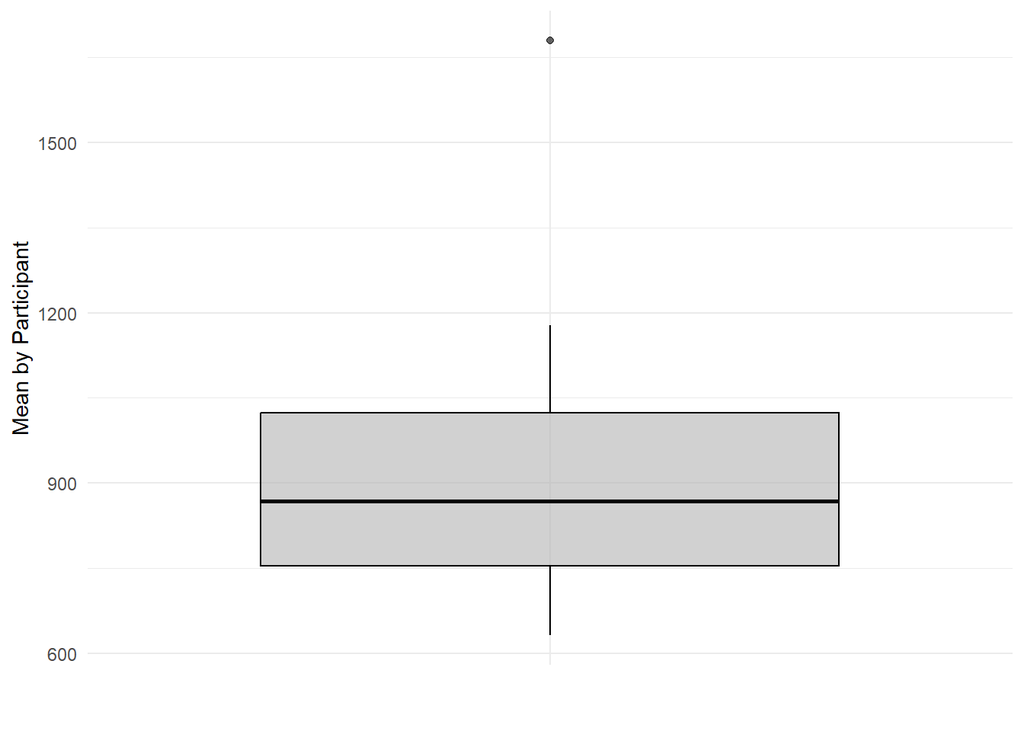

```r
# Plot
plot_outliers <- function(y_axis, filename, colour){
  p <- ggplot(data = means_by_participant, aes(x = "", y = {{ y_axis }})) +
  geom_boxplot(fill = colour, color = "black", alpha = 0.6) +
  labs(
    x = "",
    y = "Mean by Participant"
  ) +
  theme_minimal()

ggsave(
  filename,
  plot = last_plot(),
  width = 7,
  height = 5
)

p
}

plot_outliers(mean_RT, "average_RT_unfiltered.png", "grey70")
```

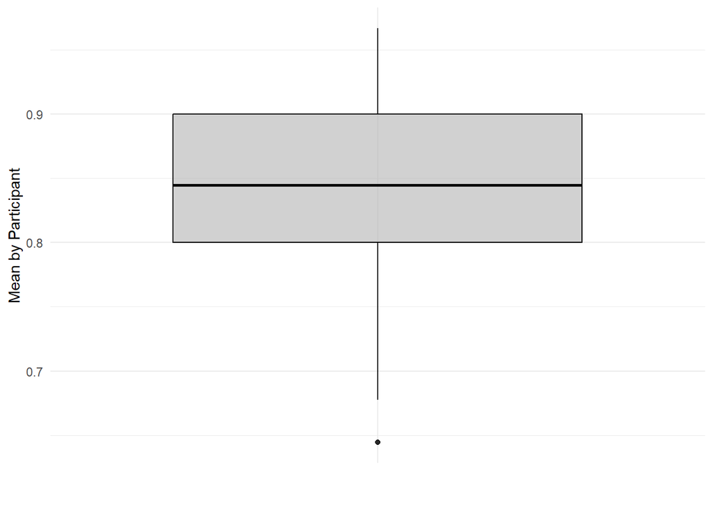

```r
plot_outliers(mean_acc, "average_acc_unfiltered.png", "grey70")
```

No participants are excluded because the participant-level descriptive statistics do not indicate problematic performance.

## Feedback coding

The feedback variable is coded as a factor with control as the reference category. This means that the model coefficients for Feedback represent the difference between the Feedback and Control conditions.

```r
filtered_df <- pre_filtered_df %>%
  mutate(
    Feedback = factor(
      Feedback,
      levels = c(0, 1),
      labels = c("Control", "Feedback")
    )
  )

filtered_df
```

```
## # A tibble: 3,330 × 29
##    Participant Item_type Condition Stimulus Accuracy    RT Feedback Length Block
##          <dbl> <chr>     <chr>     <chr>       <dbl> <dbl> <fct>     <dbl> <dbl>
##  1        2001 exp       word      COUNCIL         1   728 Feedback      7     1
##  2        2001 exp       word      ERRAND          0   533 Feedback      6     1
##  3        2001 exp       word      HAIRLINE        1   713 Feedback      8     1
##  4        2001 exp       word      SQUIRE          1   678 Feedback      6     1
##  5        2001 exp       word      LICORICE        0   488 Feedback      8     1
##  6        2001 exp       word      CIRCUIT         1   624 Feedback      7     1
##  7        2001 exp       word      BASEMENT        1   610 Feedback      8     1
##  8        2001 exp       word      VERDICT         1   616 Feedback      7     1
##  9        2001 exp       word      JESTER          0   452 Feedback      6     1
## 10        2001 exp       word      HENHOUSE        0   534 Feedback      8     1
## # ℹ 3,320 more rows
## # ℹ 20 more variables: Lg10SUBTLEX_US <dbl>, age <dbl>, gender <chr>,
## #   age_of_acquisition <dbl>, proficiency_speaking <dbl>,
## #   proficiency_listening <dbl>, proficiency_reading <dbl>,
## #   proficiency_writing <dbl>, anxiety_score <dbl>,
## #   openness_to_experience <dbl>, conscientiousness <dbl>, extraversion <dbl>,
## #   agreeableness <dbl>, neuroticism <dbl>, education <chr>, …
```

### Reaction Time Filtering

To remove implausible reaction times, a cutoff is applied.

Only trials with reaction times between **200 ms and 2000 ms** are retained.

This removes extremely fast responses (likely accidental key presses) and extremely slow responses that may reflect distractions or interruptions.

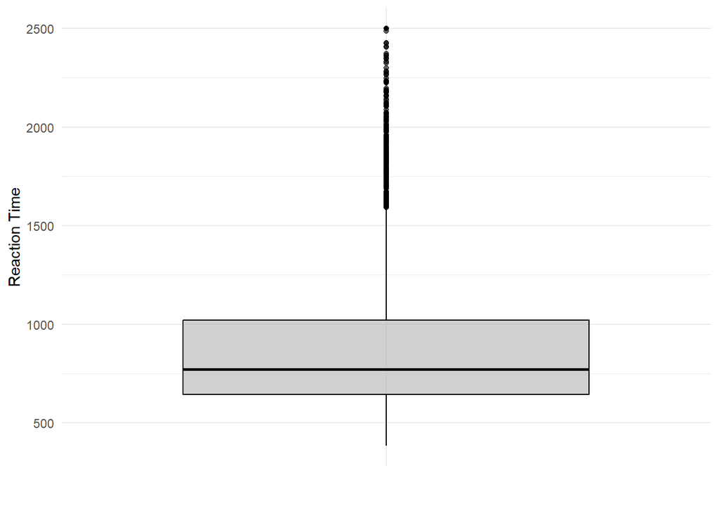

```r
# Visualize the distribution of reaction times to see where to place the cutoff
p <- ggplot(data = filtered_df, aes(x = "", y = RT)) +
  geom_boxplot(fill = "grey70", color = "black", alpha = 0.6) +
  labs(
    x = "",
    y = "Reaction Time"
  ) +
  theme_minimal()

#ggsave(
#  "RT_distribution.png",
#  plot = last_plot(),
#  width = 7,
#  height = 5
#)

p
```

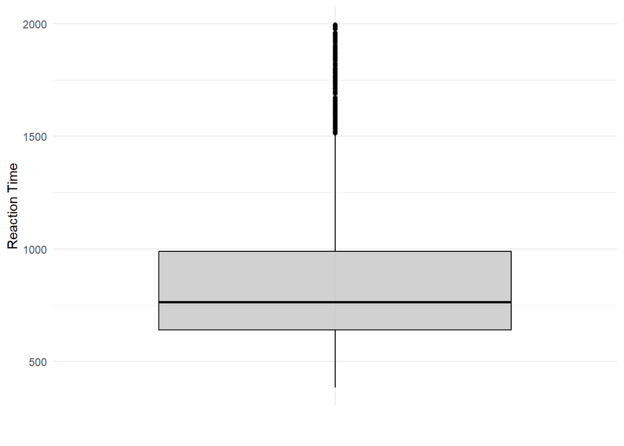

```r
# Apply cutoff
post_filtered_df <- filtered_df %>%
  filter(RT >= 200 & RT <= 2000)



# Plot again to visualize the new distribution
p <- ggplot(data = post_filtered_df, aes(x = "", y = RT)) +
  geom_boxplot(fill = "grey70", color = "black", alpha = 0.6) +
  labs(
    x = "",
    y = "Reaction Time"
  ) +
  theme_minimal()

#ggsave(
#  "RT_outlier.png",
#  plot = last_plot(),
#  width = 7,
#  height = 5
#)

p
```

### Mean Accuracy and Reaction Time by Feedback Condition

Next, mean accuracy and reaction time are computed for each feedback category:

- 1: feedback
- 0: control

```r
# Mean accuracy and reaction times by feedback condition
means_by_feedback <- post_filtered_df %>%
  group_by(Feedback) %>%
  summarise(
    mean_RT = mean(RT, na.rm = TRUE),
    mean_acc = mean(Accuracy, na.rm = TRUE)
  )
means_by_feedback
```

```
## # A tibble: 2 × 3
##   Feedback mean_RT mean_acc
##   <fct>      <dbl>    <dbl>
## 1 Control     853.    0.830
## 2 Feedback    863.    0.870
```

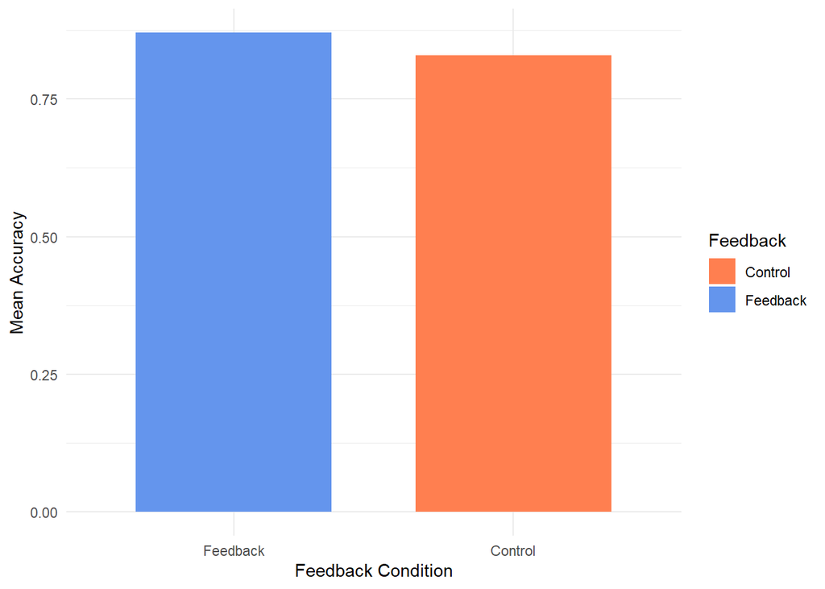

```r
# Plot mean accuracies (barplots)
p <- ggplot(
  means_by_feedback,
  aes(
    x = Feedback,
    y = mean_acc,
    fill = Feedback
  )
) +
  geom_col(
    width = 0.7
  ) +
  scale_fill_manual(
    values = feedback_colours
  ) +
  scale_x_discrete(
    limits = c("Feedback", "Control")
  ) +
  labs(
    x = "Feedback Condition",
    y = "Mean Accuracy",
    fill = "Feedback"
  ) +
  theme_minimal()

ggsave(
  "average_acc_per_feedback_barplot.png",
  plot = p,
  width = 7,
  height = 5
)

p
```

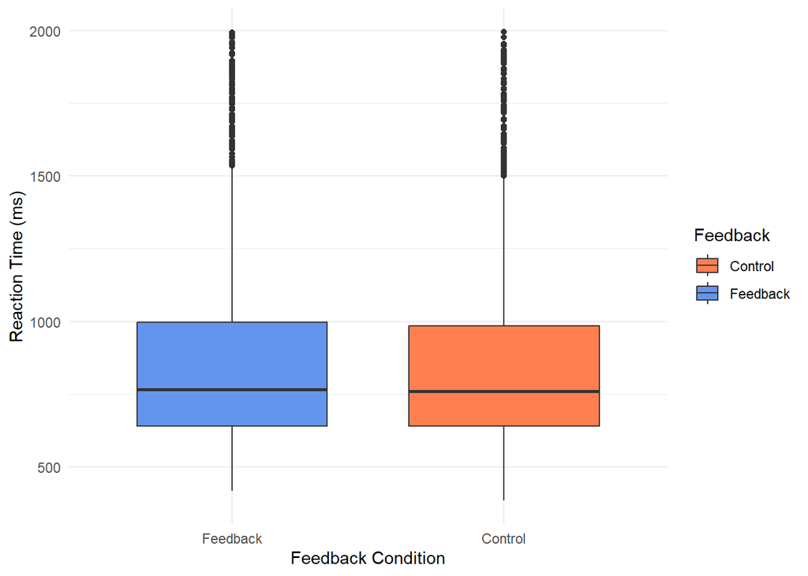

```r
# Plot mean RTs (boxplots)
p <- ggplot(
  post_filtered_df,
  aes(
    x = Feedback,
    y = RT,
    fill = Feedback
  )
) +
  geom_boxplot(
    width = 0.7
  ) +
  scale_fill_manual(
    values = feedback_colours
  ) +
  scale_x_discrete(
    limits = c("Feedback", "Control")
  ) +
  labs(
    x = "Feedback Condition",
    y = "Reaction Time (ms)",
    fill = "Feedback"
  ) +
  theme_minimal()

ggsave(
  "RT_per_feedback_boxplot.png",
  plot = p,
  width = 7,
  height = 5
)

p
```

# Inferential Statistics

To formally test the research questions, mixed-effects models are used.

Mixed-effects models are appropriate for experimental data because they allow us to account for variability across both:

- participants
- stimuli

## Data Loading and Preparation

```r
prepped_df <- post_filtered_df %>%
  mutate(
    Accuracy = as.numeric(Accuracy),
    RT = as.numeric(RT),

    Participant = factor(Participant),
    Stimulus = factor(Stimulus),

    Feedback = factor(
      Feedback,
      levels = c("Control", "Feedback")
    ),

    # Block_cat = factor(Block),           # tried to have the individual Blocks as a factorial variable but it does not work as well as having it continuous

    Block_cont = as.numeric(Block),
    anxiety_score = as.numeric(anxiety_score),
    openness_to_experience = as.numeric(openness_to_experience),
    conscientiousness = as.numeric(conscientiousness),
    extraversion = as.numeric(extraversion),
    agreeableness = as.numeric(agreeableness),
    neuroticism = as.numeric(neuroticism)
  )

prepped_df
```

```
## # A tibble: 3,231 × 30
##    Participant Item_type Condition Stimulus Accuracy    RT Feedback Length Block
##    <fct>       <chr>     <chr>     <fct>       <dbl> <dbl> <fct>     <dbl> <dbl>
##  1 2001        exp       word      COUNCIL         1   728 Feedback      7     1
##  2 2001        exp       word      ERRAND          0   533 Feedback      6     1
##  3 2001        exp       word      HAIRLINE        1   713 Feedback      8     1
##  4 2001        exp       word      SQUIRE          1   678 Feedback      6     1
##  5 2001        exp       word      LICORICE        0   488 Feedback      8     1
##  6 2001        exp       word      CIRCUIT         1   624 Feedback      7     1
##  7 2001        exp       word      BASEMENT        1   610 Feedback      8     1
##  8 2001        exp       word      VERDICT         1   616 Feedback      7     1
##  9 2001        exp       word      JESTER          0   452 Feedback      6     1
## 10 2001        exp       word      HENHOUSE        0   534 Feedback      8     1
## # ℹ 3,221 more rows
## # ℹ 21 more variables: Lg10SUBTLEX_US <dbl>, age <dbl>, gender <chr>,
## #   age_of_acquisition <dbl>, proficiency_speaking <dbl>,
## #   proficiency_listening <dbl>, proficiency_reading <dbl>,
## #   proficiency_writing <dbl>, anxiety_score <dbl>,
## #   openness_to_experience <dbl>, conscientiousness <dbl>, extraversion <dbl>,
## #   agreeableness <dbl>, neuroticism <dbl>, education <chr>, …
```

### Standardizing Continuous Predictors

Continuous predictors are standardized (z-transformed). This improves model convergence and ensures that predictors are on comparable scales. The continuous individual-difference variables are standardized before entering them into the models. This makes the coefficients easier to compare and can improve model estimation.

```r
prepped_df <- prepped_df %>%
  mutate(
    anxiety_z = as.numeric(scale(anxiety_score)),
    openness_z = as.numeric(scale(openness_to_experience)),
    conscientiousness_z = as.numeric(scale(conscientiousness)),
    extraversion_z = as.numeric(scale(extraversion)),
    agreeableness_z = as.numeric(scale(agreeableness)),
    neuroticism_z = as.numeric(scale(neuroticism)),
  )
prepped_df
```

```
## # A tibble: 3,231 × 36
##    Participant Item_type Condition Stimulus Accuracy    RT Feedback Length Block
##    <fct>       <chr>     <chr>     <fct>       <dbl> <dbl> <fct>     <dbl> <dbl>
##  1 2001        exp       word      COUNCIL         1   728 Feedback      7     1
##  2 2001        exp       word      ERRAND          0   533 Feedback      6     1
##  3 2001        exp       word      HAIRLINE        1   713 Feedback      8     1
##  4 2001        exp       word      SQUIRE          1   678 Feedback      6     1
##  5 2001        exp       word      LICORICE        0   488 Feedback      8     1
##  6 2001        exp       word      CIRCUIT         1   624 Feedback      7     1
##  7 2001        exp       word      BASEMENT        1   610 Feedback      8     1
##  8 2001        exp       word      VERDICT         1   616 Feedback      7     1
##  9 2001        exp       word      JESTER          0   452 Feedback      6     1
## 10 2001        exp       word      HENHOUSE        0   534 Feedback      8     1
## # ℹ 3,221 more rows
## # ℹ 27 more variables: Lg10SUBTLEX_US <dbl>, age <dbl>, gender <chr>,
## #   age_of_acquisition <dbl>, proficiency_speaking <dbl>,
## #   proficiency_listening <dbl>, proficiency_reading <dbl>,
## #   proficiency_writing <dbl>, anxiety_score <dbl>,
## #   openness_to_experience <dbl>, conscientiousness <dbl>, extraversion <dbl>,
## #   agreeableness <dbl>, neuroticism <dbl>, education <chr>, …
```

## Accuracy Analysis

Accuracy is analysed using a generalized linear mixed-effects model with a binomial distribution.

The primary question is whether feedback affects accuracy. Block is included to examine whether performance changes over the course of the experiment, and the interactions between Feedback and the individual-difference variables test whether personality or anxiety moderates the feedback effect.

The model includes:

Fixed effects:

- feedback
- block (time effect of being given feedback)
- each of the Big Five scores, plus the anxiety score

Random effects:

- random intercepts for participants
- random intercepts for stimuli

```r
acc_model <- glmer(
  Accuracy ~
    Feedback *
    Block_cont +
    anxiety_z +
    Feedback:anxiety_z +
    openness_z +
    Feedback:openness_z +
    conscientiousness_z +
    Feedback:conscientiousness_z +
    extraversion_z +
    Feedback:extraversion_z +
    agreeableness_z +
    Feedback:agreeableness_z +
    neuroticism_z +
    Feedback:neuroticism_z +
    (1 | Participant) +
    (1 | Stimulus),
  family = binomial,
  data = prepped_df,
  control = glmerControl(
    optimizer = "bobyqa",
    optCtrl = list(maxfun = 1e5)
  )
)

summary(acc_model)
```

```
## Generalized linear mixed model fit by maximum likelihood (Laplace
##   Approximation) [glmerMod]
##  Family: binomial  ( logit )
## Formula: Accuracy ~ Feedback * Block_cont + anxiety_z + Feedback:anxiety_z +
##     openness_z + Feedback:openness_z + conscientiousness_z +
##     Feedback:conscientiousness_z + extraversion_z + Feedback:extraversion_z +
##     agreeableness_z + Feedback:agreeableness_z + neuroticism_z +
##     Feedback:neuroticism_z + (1 | Participant) + (1 | Stimulus)
##    Data: prepped_df
## Control: glmerControl(optimizer = "bobyqa", optCtrl = list(maxfun = 1e+05))
##
##       AIC       BIC    logLik -2*log(L)  df.resid
##    2057.1    2166.6   -1010.6    2021.1      3213
##
## Scaled residuals:
##     Min      1Q  Median      3Q     Max
## -9.9456  0.0931  0.1749  0.3278  3.7865
##
## Random effects:
##  Groups      Name        Variance Std.Dev.
##  Stimulus    (Intercept) 3.3702   1.8358
##  Participant (Intercept) 0.2402   0.4901
## Number of obs: 3231, groups:  Stimulus, 90; Participant, 37
##
## Fixed effects:
##                                      Estimate Std. Error z value Pr(>|z|)
## (Intercept)                           2.62532    0.30179   8.699  < 2e-16 ***
## FeedbackFeedback                      0.27880    0.33017   0.844  0.39843
## Block_cont                           -0.02840    0.04687  -0.606  0.54461
## anxiety_z                            -0.54383    0.17281  -3.147  0.00165 **
## openness_z                            0.22441    0.13404   1.674  0.09410 .
## conscientiousness_z                  -0.34907    0.16673  -2.094  0.03630 *
## extraversion_z                       -0.84803    0.20947  -4.049 5.15e-05 ***
## agreeableness_z                       0.12133    0.15967   0.760  0.44731
## neuroticism_z                        -0.23740    0.19410  -1.223  0.22128
## FeedbackFeedback:Block_cont           0.05994    0.07170   0.836  0.40311
## FeedbackFeedback:anxiety_z           -0.03333    0.23938  -0.139  0.88927
## FeedbackFeedback:openness_z          -0.44671    0.24531  -1.821  0.06861 .
## FeedbackFeedback:conscientiousness_z  0.12874    0.22875   0.563  0.57358
## FeedbackFeedback:extraversion_z       0.75703    0.28780   2.630  0.00853 **
## FeedbackFeedback:agreeableness_z     -0.09297    0.25801  -0.360  0.71859
## FeedbackFeedback:neuroticism_z        0.33409    0.25773   1.296  0.19487
## ---
## Signif. codes:  0 '***' 0.001 '**' 0.01 '*' 0.05 '.' 0.1 ' ' 1
```

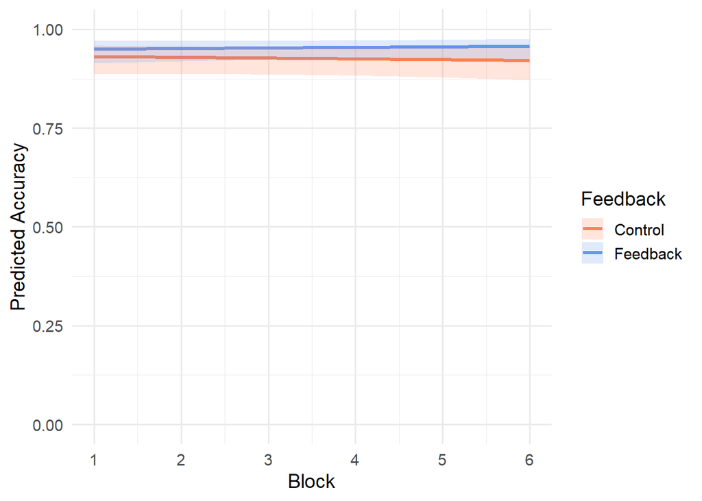

```r
# Plot the model

block_seq <- seq(
  min(prepped_df$Block_cont, na.rm = TRUE),
  max(prepped_df$Block_cont, na.rm = TRUE),
  by = 0.1
)

# Estimated marginal means
# Personality variables are held at their mean (0)
emm <- emmeans(
  acc_model,
  ~ Feedback | Block_cont,
  at = list(
    Block_cont = block_seq,
    anxiety_z = 0,
    openness_z = 0,
    conscientiousness_z = 0,
    extraversion_z = 0,
    agreeableness_z = 0,
    neuroticism_z = 0
  ),
  type = "response"
)

# Convert to dataframe
emm_df <- as.data.frame(emm)

# Plot
p <- ggplot(
  emm_df,
  aes(
    x = Block_cont,
    y = prob,
    color = Feedback,
    fill = Feedback
  )
) +
  geom_line(linewidth = 1.2) +
  geom_ribbon(
    aes(
      ymin = asymp.LCL,
      ymax = asymp.UCL
    ),
    alpha = 0.2,
    color = NA
  ) +
  scale_color_manual(
    values = feedback_colours
  ) +
  scale_fill_manual(
    values = feedback_colours
  ) +
  labs(
    x = "Block",
    y = "Predicted Accuracy",
    color = "Feedback",
    fill = "Feedback"
  ) +
  scale_x_continuous(
    breaks = 1:6
  ) +
  scale_y_continuous(
    limits = c(0, 1)
  ) +
  theme_minimal(base_size = 14)

ggsave(
  "acc_model_feedback_block.png",
  plot = p,
  width = 7,
  height = 5
)

p
```

## Reaction Time Analysis

Reaction times are analysed using a **linear mixed-effects model**.

Only trials with correct responses are included, as incorrect trials may reflect different cognitive processes.

The model includes:

Fixed effects:

- feedback
- block (time effect of being given feedback)
- each of the Big Five scores, plus the anxiety score

Random effects:

- random intercepts for participants
- random intercepts for stimuli

```r
RT_df <- prepped_df %>%
  filter(Accuracy == 1)

RT_df
```

```
## # A tibble: 2,744 × 36
##    Participant Item_type Condition Stimulus Accuracy    RT Feedback Length Block
##    <fct>       <chr>     <chr>     <fct>       <dbl> <dbl> <fct>     <dbl> <dbl>
##  1 2001        exp       word      COUNCIL         1   728 Feedback      7     1
##  2 2001        exp       word      HAIRLINE        1   713 Feedback      8     1
##  3 2001        exp       word      SQUIRE          1   678 Feedback      6     1
##  4 2001        exp       word      CIRCUIT         1   624 Feedback      7     1
##  5 2001        exp       word      BASEMENT        1   610 Feedback      8     1
##  6 2001        exp       word      VERDICT         1   616 Feedback      7     1
##  7 2001        exp       word      BRAKE           1   582 Feedback      5     1
##  8 2001        exp       word      OVERSEER        1   557 Feedback      8     2
##  9 2001        exp       word      BOOKIE          1   791 Feedback      6     2
## 10 2001        exp       word      TENANT          1   589 Feedback      6     2
## # ℹ 2,734 more rows
## # ℹ 27 more variables: Lg10SUBTLEX_US <dbl>, age <dbl>, gender <chr>,
## #   age_of_acquisition <dbl>, proficiency_speaking <dbl>,
## #   proficiency_listening <dbl>, proficiency_reading <dbl>,
## #   proficiency_writing <dbl>, anxiety_score <dbl>,
## #   openness_to_experience <dbl>, conscientiousness <dbl>, extraversion <dbl>,
## #   agreeableness <dbl>, neuroticism <dbl>, education <chr>, …
```

The model uses the same predictors as the accuracy model.

```r
RT_model <- lmer(
  RT ~
    Feedback *
    Block_cont +
    anxiety_z +
    Feedback:anxiety_z +
    openness_z +
    Feedback:openness_z +
    conscientiousness_z +
    Feedback:conscientiousness_z +
    extraversion_z +
    Feedback:extraversion_z +
    agreeableness_z +
    Feedback:agreeableness_z +
    neuroticism_z +
    Feedback:neuroticism_z +
    (1 | Participant) +
    (1 | Stimulus),
  data = RT_df
)

summary(RT_model)
```

```
## Linear mixed model fit by REML. t-tests use Satterthwaite's method [
## lmerModLmerTest]
## Formula: RT ~ Feedback * Block_cont + anxiety_z + Feedback:anxiety_z +
##     openness_z + Feedback:openness_z + conscientiousness_z +
##     Feedback:conscientiousness_z + extraversion_z + Feedback:extraversion_z +
##     agreeableness_z + Feedback:agreeableness_z + neuroticism_z +
##     Feedback:neuroticism_z + (1 | Participant) + (1 | Stimulus)
##    Data: RT_df
##
## REML criterion at convergence: 37601.9
##
## Scaled residuals:
##     Min      1Q  Median      3Q     Max
## -2.6088 -0.5803 -0.1961  0.3265  5.9044
##
## Random effects:
##  Groups      Name        Variance Std.Dev.
##  Stimulus    (Intercept) 11556    107.5
##  Participant (Intercept) 25101    158.4
##  Residual                49293    222.0
## Number of obs: 2744, groups:  Stimulus, 90; Participant, 37
##
## Fixed effects:
##                                      Estimate Std. Error       df t value
## (Intercept)                           897.764     41.514   32.948  21.626
## FeedbackFeedback                       37.715     57.764   28.043   0.653
## Block_cont                            -10.347      3.583 2632.237  -2.888
## anxiety_z                               8.524     45.965   23.027   0.185
## openness_z                             19.458     35.806   23.014   0.543
## conscientiousness_z                     8.222     44.252   23.030   0.186
## extraversion_z                         59.459     52.855   22.910   1.125
## agreeableness_z                        30.101     41.329   22.943   0.728
## neuroticism_z                           4.667     49.948   22.917   0.093
## FeedbackFeedback:Block_cont            -4.770      5.084 2632.942  -0.938
## FeedbackFeedback:anxiety_z             12.976     62.770   22.977   0.207
## FeedbackFeedback:openness_z            -9.166     63.533   22.947  -0.144
## FeedbackFeedback:conscientiousness_z   70.314     60.549   23.018   1.161
## FeedbackFeedback:extraversion_z      -120.246     72.183   22.890  -1.666
## FeedbackFeedback:agreeableness_z     -157.898     66.466   23.000  -2.376
## FeedbackFeedback:neuroticism_z        -32.544     67.178   22.947  -0.484
##                                      Pr(>|t|)
## (Intercept)                           < 2e-16 ***
## FeedbackFeedback                      0.51912
## Block_cont                            0.00391 **
## anxiety_z                             0.85451
## openness_z                            0.59207
## conscientiousness_z                   0.85423
## extraversion_z                        0.27227
## agreeableness_z                       0.47378
## neuroticism_z                         0.92637
## FeedbackFeedback:Block_cont           0.34820
## FeedbackFeedback:anxiety_z            0.83804
## FeedbackFeedback:openness_z           0.88654
## FeedbackFeedback:conscientiousness_z  0.25743
## FeedbackFeedback:extraversion_z       0.10937
## FeedbackFeedback:agreeableness_z      0.02623 *
## FeedbackFeedback:neuroticism_z        0.63266
## ---
## Signif. codes:  0 '***' 0.001 '**' 0.01 '*' 0.05 '.' 0.1 ' ' 1
```

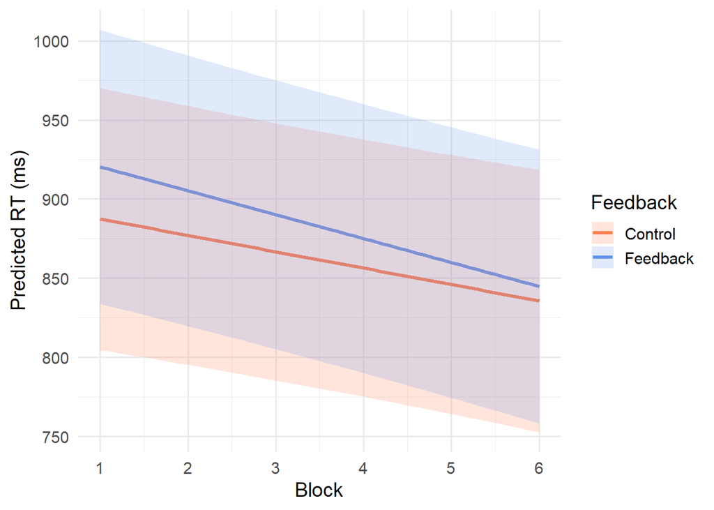

```r
# Plot the model
# Block as a continuous predictor

block_seq <- seq(
  min(RT_df$Block_cont, na.rm = TRUE),
  max(RT_df$Block_cont, na.rm = TRUE),
  by = 0.1
)

# Estimated marginal means
# Personality variables are held at their mean (0)
emm <- emmeans(
  RT_model,
  ~ Feedback | Block_cont,
  at = list(
    Block_cont = block_seq,
    anxiety_z = 0,
    openness_z = 0,
    conscientiousness_z = 0,
    extraversion_z = 0,
    agreeableness_z = 0,
    neuroticism_z = 0
  )
)

# Convert to dataframe
emm_df <- as.data.frame(emm)

# Plot
p <- ggplot(
  emm_df,
  aes(
    x = Block_cont,
    y = emmean,
    color = Feedback,
    fill = Feedback
  )
) +
  geom_line(linewidth = 1.2) +
  geom_ribbon(
    aes(
      ymin = lower.CL,
      ymax = upper.CL
    ),
    alpha = 0.2,
    color = NA
  ) +
  scale_color_manual(
    values = feedback_colours
  ) +
  scale_fill_manual(
    values = feedback_colours
  ) +
  labs(
    x = "Block",
    y = "Predicted RT (ms)",
    color = "Feedback",
    fill = "Feedback"
  ) +
  scale_x_continuous(
    breaks = 1:6
  ) +
  theme_minimal(base_size = 14)

ggsave(
  "RT_model_feedback_block.png",
  plot = p,
  width = 7,
  height = 5
)

p
```

# Interpretation

The results of the mixed-effects models are interpreted with respect to the research questions:

1. Does summary accuracy feedback affect lexical decision performance, as reflected in reaction times and accuracy?
2. Do Big Five personality traits and foreign language anxiety moderate the effect of feedback on performance?
3. Does the effect of feedback change over the course of the experiment?

The answers to these questions are based on the inferential statistical results reported above.